# Part I - PISA Data Analysis

## Preliminary Wrangling

```python
# import all neccesary packages
import numpy as np
import pandas as pd
import matplotlib.pyplot as plt
import seaborn as sb
from matplotlib.pyplot import xticks

%matplotlib inline
```

```python
#Read in the csv file into a dataframe and display the first 10 rows
df = pd.read_csv('pisa2012.csv', encoding='latin-1')
df.head(10)
```

|  | Unnamed: 0 | CNT | SUBNATIO | STRATUM | OECD | NC | SCHOOLID | STIDSTD | ST01Q01 | ST02Q01 | ... | W_FSTR75 | W_FSTR76 | W_FSTR77 | W_FSTR78 | W_FSTR79 | W_FSTR80 | WVARSTRR | VAR_UNIT | SENWGT_STU | VER_STU |
| --- | --- | --- | --- | --- | --- | --- | --- | --- | --- | --- | --- | --- | --- | --- | --- | --- | --- | --- | --- | --- | --- |
| 0 | 1 | Albania | 80000 | ALB0006 | Non-OECD | Albania | 1 | 1 | 10 | 1.0 | ... | 13.7954 | 13.9235 | 13.1249 | 13.1249 | 4.3389 | 13.0829 | 19 | 1 | 0.2098 | 22NOV13 |
| 1 | 2 | Albania | 80000 | ALB0006 | Non-OECD | Albania | 1 | 2 | 10 | 1.0 | ... | 13.7954 | 13.9235 | 13.1249 | 13.1249 | 4.3389 | 13.0829 | 19 | 1 | 0.2098 | 22NOV13 |
| 2 | 3 | Albania | 80000 | ALB0006 | Non-OECD | Albania | 1 | 3 | 9 | 1.0 | ... | 12.7307 | 12.7307 | 12.7307 | 12.7307 | 4.2436 | 12.7307 | 19 | 1 | 0.1999 | 22NOV13 |
| 3 | 4 | Albania | 80000 | ALB0006 | Non-OECD | Albania | 1 | 4 | 9 | 1.0 | ... | 12.7307 | 12.7307 | 12.7307 | 12.7307 | 4.2436 | 12.7307 | 19 | 1 | 0.1999 | 22NOV13 |
| 4 | 5 | Albania | 80000 | ALB0006 | Non-OECD | Albania | 1 | 5 | 9 | 1.0 | ... | 12.7307 | 12.7307 | 12.7307 | 12.7307 | 4.2436 | 12.7307 | 19 | 1 | 0.1999 | 22NOV13 |
| 5 | 6 | Albania | 80000 | ALB0006 | Non-OECD | Albania | 1 | 6 | 9 | 1.0 | ... | 12.7307 | 12.7307 | 12.7307 | 12.7307 | 4.2436 | 12.7307 | 19 | 1 | 0.1999 | 22NOV13 |
| 6 | 7 | Albania | 80000 | ALB0006 | Non-OECD | Albania | 1 | 7 | 10 | 1.0 | ... | 13.7954 | 13.9235 | 13.1249 | 13.1249 | 4.3389 | 13.0829 | 19 | 1 | 0.2098 | 22NOV13 |
| 7 | 8 | Albania | 80000 | ALB0006 | Non-OECD | Albania | 1 | 8 | 10 | 1.0 | ... | 14.4599 | 14.6374 | 15.8728 | 15.8728 | 5.2248 | 15.2579 | 19 | 1 | 0.2322 | 22NOV13 |
| 8 | 9 | Albania | 80000 | ALB0006 | Non-OECD | Albania | 1 | 9 | 9 | 1.0 | ... | 12.7307 | 12.7307 | 12.7307 | 12.7307 | 4.2436 | 12.7307 | 19 | 1 | 0.1999 | 22NOV13 |
| 9 | 10 | Albania | 80000 | ALB0005 | Non-OECD | Albania | 2 | 10 | 10 | 1.0 | ... | 3.3844 | 10.1533 | 3.3844 | 10.1533 | 10.1533 | 10.1533 | 74 | 2 | 0.1594 | 22NOV13 |

10 rows × 636 columns

```python
df.info()
```

```
<class 'pandas.core.frame.DataFrame'>
RangeIndex: 485490 entries, 0 to 485489
Columns: 636 entries, Unnamed: 0 to VER_STU
dtypes: float64(250), int64(18), object(368)
memory usage: 2.3+ GB
```

```python
df.columns
```

```
Index(['Unnamed: 0', 'CNT', 'SUBNATIO', 'STRATUM', 'OECD', 'NC', 'SCHOOLID',
       'STIDSTD', 'ST01Q01', 'ST02Q01',
       ...
       'W_FSTR75', 'W_FSTR76', 'W_FSTR77', 'W_FSTR78', 'W_FSTR79', 'W_FSTR80',
       'WVARSTRR', 'VAR_UNIT', 'SENWGT_STU', 'VER_STU'],
      dtype='object', length=636)
```

```python
#For this project, We are going to focus on the following variables
cols = ['STIDSTD','CNT','SCHOOLID','ST01Q01','ST04Q01','ST11Q01','ST26Q04',
       'ST28Q01','ST57Q03','ST86Q01','ST87Q09','ST88Q02','ST89Q05','ST93Q04',
       'IC01Q04','AGE','HISCED','OUTHOURS','REPEAT']
```

```python
pisa_df = df[cols]
```

```python
pisa_df.columns
```

```
Index(['STIDSTD', 'CNT', 'SCHOOLID', 'ST01Q01', 'ST04Q01', 'ST11Q01',
       'ST26Q04', 'ST28Q01', 'ST57Q03', 'ST86Q01', 'ST87Q09', 'ST88Q02',
       'ST89Q05', 'ST93Q04', 'IC01Q04', 'AGE', 'HISCED', 'OUTHOURS', 'REPEAT'],
      dtype='object')
```

```python
pisa_df.describe()
```

|  | STIDSTD | SCHOOLID | ST01Q01 | ST57Q03 | AGE | OUTHOURS |
| --- | --- | --- | --- | --- | --- | --- |
| count | 485490.000000 | 485490.000000 | 485490.000000 | 283813.000000 | 485374.000000 | 308799.000000 |
| mean | 6134.066201 | 240.152197 | 9.813323 | 0.954044 | 15.784283 | 11.104100 |
| std | 6733.144944 | 278.563016 | 3.734726 | 2.162574 | 0.290221 | 10.476669 |
| min | 1.000000 | 1.000000 | 7.000000 | 0.000000 | 15.170000 | 0.000000 |
| 25% | 1811.000000 | 61.000000 | 9.000000 | 0.000000 | 15.580000 | 4.000000 |
| 50% | 3740.000000 | 136.000000 | 10.000000 | 0.000000 | 15.750000 | 8.000000 |
| 75% | 7456.000000 | 291.000000 | 10.000000 | 1.000000 | 16.000000 | 14.000000 |
| max | 33806.000000 | 1471.000000 | 96.000000 | 30.000000 | 16.330000 | 180.000000 |

```python
pisa_df.info()
```

```
<class 'pandas.core.frame.DataFrame'>
RangeIndex: 485490 entries, 0 to 485489
Data columns (total 19 columns):
STIDSTD     485490 non-null int64
CNT         485490 non-null object
SCHOOLID    485490 non-null int64
ST01Q01     485490 non-null int64
ST04Q01     485490 non-null object
ST11Q01     460559 non-null object
ST26Q04     473877 non-null object
ST28Q01     473765 non-null object
ST57Q03     283813 non-null float64
ST86Q01     313223 non-null object
ST87Q09     311101 non-null object
ST88Q02     310964 non-null object
ST89Q05     311138 non-null object
ST93Q04     311311 non-null object
IC01Q04     297305 non-null object
AGE         485374 non-null float64
HISCED      473091 non-null object
OUTHOURS    308799 non-null float64
REPEAT      461117 non-null object
dtypes: float64(3), int64(3), object(13)
memory usage: 70.4+ MB
```

```python
# We rename columns for easier interpretation
pisa_df = pisa_df.rename(columns ={'STIDSTD':'Student_ID','CNT':'Country_Code'
    ,'SCHOOLID': 'School_ID','ST01Q01':'InternationalGrade','ST04Q01':'Gender','ST11Q01':'MotherAtHOME','ST26Q04':'ComputerPosession',
    'ST28Q01':'BooksAtHome','ST57Q03':'PersonalTutor','ST86Q01':'GetAlongWithTeachers',
        'ST87Q09':'SatisfiedAtSchool','ST88Q02':'Attitude_WasteOfTime'
        ,'ST89Q05':'Attitude_TryingHardImportant','ST93Q04':'Perseverance_RemainInterested',
       'IC01Q04':'AtHome_Internet','AGE': 'Age','HISCED':'Highest_Edu_Parents'
    ,'OUTHOURS':'OutOfSchool_StudyTime','REPEAT':'Repeat_Grade',})
```

```python
pisa_df.info()
```

```
<class 'pandas.core.frame.DataFrame'>
RangeIndex: 485490 entries, 0 to 485489
Data columns (total 19 columns):
Student_ID                       485490 non-null int64
Country_Code                     485490 non-null object
School_ID                        485490 non-null int64
InternationalGrade               485490 non-null int64
Gender                           485490 non-null object
MotherAtHOME                     460559 non-null object
ComputerPosession                473877 non-null object
BooksAtHome                      473765 non-null object
PersonalTutor                    283813 non-null float64
GetAlongWithTeachers             313223 non-null object
SatisfiedAtSchool                311101 non-null object
Attitude_WasteOfTime             310964 non-null object
Attitude_TryingHardImportant     311138 non-null object
Perseverance_RemainInterested    311311 non-null object
AtHome_Internet                  297305 non-null object
Age                              485374 non-null float64
Highest_Edu_Parents              473091 non-null object
OutOfSchool_StudyTime            308799 non-null float64
Repeat_Grade                     461117 non-null object
dtypes: float64(3), int64(3), object(13)
memory usage: 70.4+ MB
```

**We must sort out NaN values in all the columns we intend to use in our analysis**

```python
#Replace Nan values with most frequent response
pisa_df[['MotherAtHOME', 'ComputerPosession']] = pisa_df[['MotherAtHOME', 'ComputerPosession']].fillna('Yes')
```

```python
#Replace Nan values with most frequent response
pisa_df[['GetAlongWithTeachers', 'SatisfiedAtSchool']] = pisa_df[['GetAlongWithTeachers', 'SatisfiedAtSchool']].fillna('Agree')
```

```python
def replace_nan(feature1,feature2):
    pisa_df[feature1] = pisa_df[feature1].fillna(feature2)
```

```python
#Replace Nan values with 0-10 range
replace_nan('BooksAtHome','0-10 books ')
```

```python
#Replace Nan values with 0
replace_nan('PersonalTutor',0.0)
```

```python
#Replace Nan values with most frequent response
replace_nan('Attitude_WasteOfTime','Disagree')
```

```python
#Replace Nan values with most frequent response
replace_nan('Attitude_TryingHardImportant','Strongly agree')
```

```python
#Replace Nan values with most frequent response
replace_nan('Perseverance_RemainInterested','Mostly like me')
```

```python
#Replace Nan values with most frequent response
replace_nan('AtHome_Internet','Yes, and I use it')
```

```python
#Replace Nan values with the mean
replace_nan('Age',  15.58)
```

```python
#Replace Nan values with most frequent response
replace_nan('Highest_Edu_Parents', 'ISCED 5A, 6')
```

```python
#Replace Nan values with the mean
replace_nan('OutOfSchool_StudyTime',   11.)
```

```python
#Replace Nan values with most frequent response
replace_nan('Repeat_Grade','Did not repeat a <grade>')
```

```python
print(" rows = {} and columns= {}".format(df.shape[0], pisa_df.shape[1]))
```

```
 rows = 485490 and columns= 19
```

## Identify the datatype for each variable

```python
pisa_df.dtypes
```

```
Student_ID                         int64
Country_Code                      object
School_ID                          int64
InternationalGrade                 int64
Gender                            object
MotherAtHOME                      object
ComputerPosession                 object
BooksAtHome                       object
PersonalTutor                    float64
GetAlongWithTeachers              object
SatisfiedAtSchool                 object
Attitude_WasteOfTime              object
Attitude_TryingHardImportant      object
Perseverance_RemainInterested     object
AtHome_Internet                   object
Age                              float64
Highest_Edu_Parents               object
OutOfSchool_StudyTime            float64
Repeat_Grade                      object
dtype: object
```

### What is the structure of your dataset?

> The dataset contains 485490 (rows) and 19 (columns).

### What is/are the main feature(s) of interest in your dataset?

> The main feature of interest is International Grade, which indicates how well a student has performed academically.

### What features in the dataset do you think will help support your investigation into your feature(s) of interest?

> Features such as whether a student has a computer at home, a personal tutor, their satisfaction at school and their attitudes towards school will help support my investigation.

## Univariate Exploration

```python
pisa_df.columns
```

```
Index(['Student_ID', 'Country_Code', 'School_ID', 'InternationalGrade',
       'Gender', 'MotherAtHOME', 'ComputerPosession', 'BooksAtHome',
       'PersonalTutor', 'GetAlongWithTeachers', 'SatisfiedAtSchool',
       'Attitude_WasteOfTime', 'Attitude_TryingHardImportant',
       'Perseverance_RemainInterested', 'AtHome_Internet', 'Age',
       'Highest_Edu_Parents', 'OutOfSchool_StudyTime', 'Repeat_Grade'],
      dtype='object')
```

```python
pisa_df.Country_Code.value_counts()
```

```
Mexico                      33806
Italy                       31073
Spain                       25313
Canada                      21544
Brazil                      19204
Australia                   14481
United Kingdom              12659
United Arab Emirates        11500
Switzerland                 11229
Qatar                       10966
Colombia                     9073
Finland                      8829
Belgium                      8597
Denmark                      7481
Jordan                       7038
Chile                        6856
Thailand                     6606
Japan                        6351
Chinese Taipei               6046
Peru                         6035
Slovenia                     5911
Argentina                    5908
Kazakhstan                   5808
Portugal                     5722
Indonesia                    5622
Singapore                    5546
Macao-China                  5335
Czech Republic               5327
Uruguay                      5315
Bulgaria                     5282
                            ...
Ireland                      5016
Croatia                      5008
Germany                      5001
United States of America     4978
Vietnam                      4959
Turkey                       4848
Hungary                      4810
Estonia                      4779
Austria                      4755
Montenegro                   4744
Albania                      4743
Sweden                       4736
Norway                       4686
Serbia                       4684
Slovak Republic              4678
Hong Kong-China              4670
Lithuania                    4618
France                       4613
Poland                       4607
Costa Rica                   4602
Netherlands                  4460
Tunisia                      4407
Latvia                       4306
New Zealand                  4291
Iceland                      3508
Florida (USA)                1896
Perm(Russian Federation)     1761
Massachusetts (USA)          1723
Connecticut (USA)            1697
Liechtenstein                 293
Name: Country_Code, Length: 68, dtype: int64
```

```python
pisa_df.Gender.value_counts()
```

```
Female    245064
Male      240426
Name: Gender, dtype: int64
```

```python
pisa_df.Age.value_counts()
```

```
15.58    42878
15.67    42353
15.75    41664
15.83    41402
15.92    41084
16.00    41049
15.42    40437
15.50    40291
16.08    39313
16.17    38356
15.33    28354
16.25    26139
15.25    11986
16.33    10183
15.17        1
Name: Age, dtype: int64
```

```python
pisa_df.PersonalTutor.value_counts()
```

```
0.0     393375
1.0      28923
2.0      28766
3.0      10845
4.0       8966
5.0       4086
6.0       3841
8.0       1401
7.0       1238
10.0      1197
9.0       1027
12.0       465
14.0       237
30.0       210
20.0       185
15.0       172
11.0       125
24.0        80
18.0        71
13.0        68
16.0        63
21.0        35
25.0        32
28.0        23
17.0        20
19.0        12
23.0         9
22.0         6
26.0         6
29.0         3
27.0         3
Name: PersonalTutor, dtype: int64
```

## Now we look at International Grade, our main variable of interest, what is the distribution ?

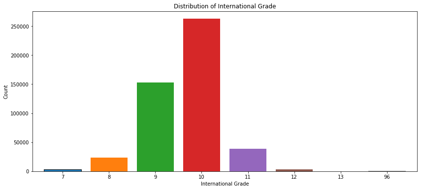

```python
#plot bar chart to show distribution of International grade
pisa_df['InternationalGrade'].value_counts().sort_index().plot.bar(edgecolor ='black',figsize = [14,6],rot=0,width=0.8);
plt.xlabel('International Grade')
plt.ylabel('Count')
plt.title('Distribution of International Grade')
plt.show()
```

**We can observe that students have grades between 7 and 13, with 96 being an outlier . A grade score of 10 is the most populous grade class by some margin.**

## Now for the features that will support our investigation, starting with how many hours a student spends with a personal tutor at home, what is the distribution ?

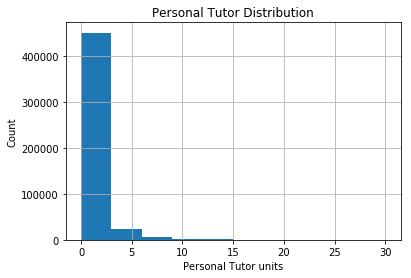

```python
#plot histogram chart to show distribution of Personal Tutor
pisa_df.hist(column='PersonalTutor')
plt.xlabel('Personal Tutor units')
plt.ylabel('Count')
plt.title('Personal Tutor Distribution')
plt.show()
```

**The distribution is heavily skewed to the right, majority of students have 0 to 2.5 units personal tutoring**

## What is the Gender distribution?

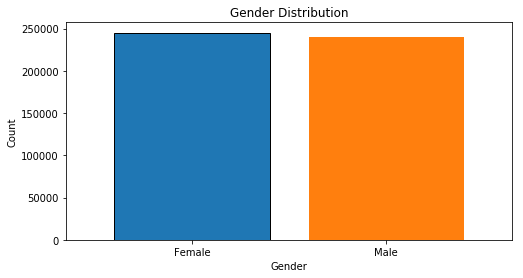

```python
#plot bar chart to show distribution of Gender
pisa_df['Gender'].value_counts().sort_index().plot.bar(edgecolor ='black',figsize = [8,4],rot=0,width=0.8);
plt.xlabel('Gender')
plt.ylabel('Count')
plt.title('Gender Distribution')
plt.show()
```

**The are slightly more Female participants than male in the dataset**

## What proportion of participants have computers at home?

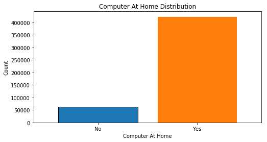

```python
#plot bar chart to show distribution of computer at home status
pisa_df['ComputerPosession'].value_counts().sort_index().plot.bar(edgecolor ='black',figsize = [8,4],rot=0,width=0.8);
plt.xlabel('Computer At Home')
plt.ylabel('Count')
plt.title('Computer At Home Distribution')
plt.show()
```

**A vast majority of participants have computers at home**

## What is the Age ditribution of participants?

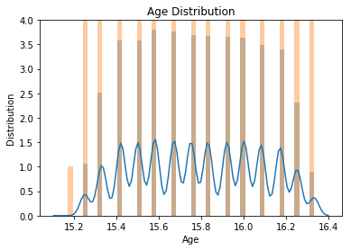

```python
#plot distribution of Age
sb.distplot(pisa_df['Age'])
sb.distplot(pisa_df['Age'], kde=False)
plt.xlabel('Age')
plt.ylabel('Distribution')
plt.title('Age Distribution')
plt.show()
```

**The age spread is fairly evenly spread, with at peak around 15.6**

## lets examine time spent studying out of school

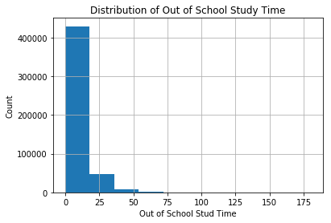

```python
#plot histogram to show distribution of Out of school study time
pisa_df.hist(column='OutOfSchool_StudyTime')
plt.xlabel('Out of School Stud Time')
plt.ylabel('Count')
plt.title('Distribution of Out of School Study Time')
plt.show()
```

**Majority of students spend less than 25 units studying outside of school**

### Discuss the distribution(s) of your variable(s) of interest. Were there any unusual points? Did you need to perform any transformations?

> **We can observe that students have grades between 7 and 13, with 96 being an outlier . A grade score of 10 is the most populous grade class by some margin.**

### Of the features you investigated, were there any unusual distributions? Did you perform any operations on the data to tidy, adjust, or change the form of the data? If so, why did you do this?

> **Personal Tutor, Computer Posession and Age had Nan values which had to be tidied prior to vizualisation. Nan values were replaced with either mean or mode values.**

## Is International grade distribution peculiar to Gender?

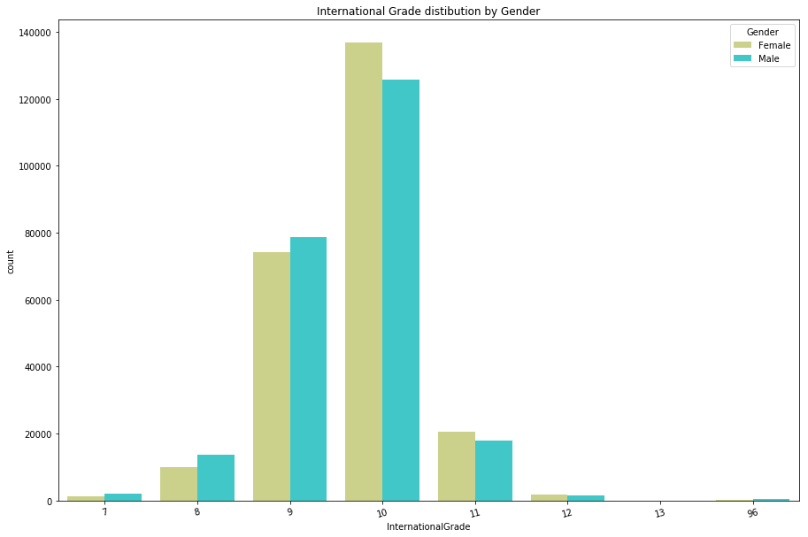

```python
# plot stacked bar chart
plt.figure(figsize = [15, 10])
sb.countplot(data = pisa_df, x = 'InternationalGrade', hue = 'Gender', palette = 'rainbow_r')
plt.xticks(rotation = 15);
plt.title('International Grade distibution by Gender')
plt.show()
```

## Is International grade distribution peculiar to Computer Posession?

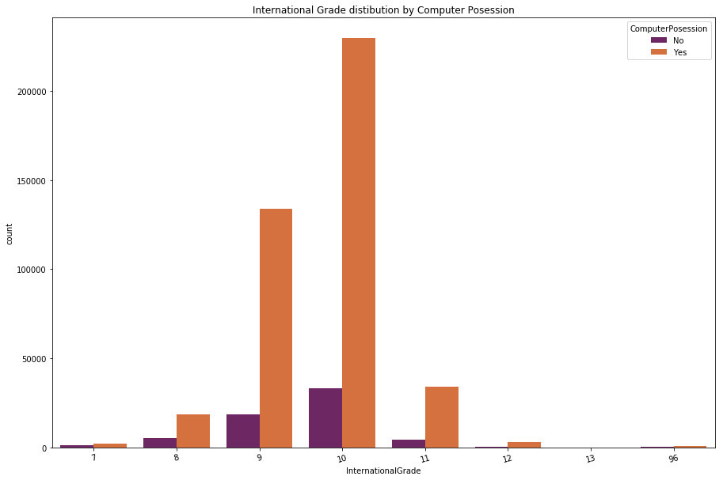

```python
# plot stacked chart
plt.figure(figsize = [15, 10])
sb.countplot(data = pisa_df, x = 'InternationalGrade', hue = 'ComputerPosession',palette = 'inferno')
plt.xticks(rotation = 15);
plt.title('International Grade distibution by Computer Posession')
plt.show()
```

**In the two highest grade bands (11&12) we observe that only a tiny amount of participants do not have computers at home**

## Is International grade distribution peculiar to how well participants get on with teachers?

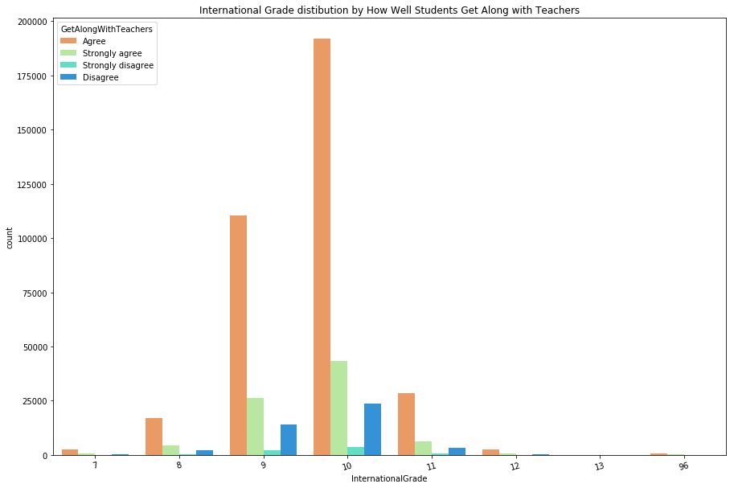

```python
# plot stacked bar chart
plt.figure(figsize = [15, 10])
sb.countplot(data = pisa_df, x = 'InternationalGrade', hue = 'GetAlongWithTeachers', palette = 'rainbow_r')
plt.xticks(rotation = 15);
plt.title('International Grade distibution by How Well Students Get Along with Teachers')
plt.show()
```

## Is International grade distribution peculiar to participants' ability to remain interested?

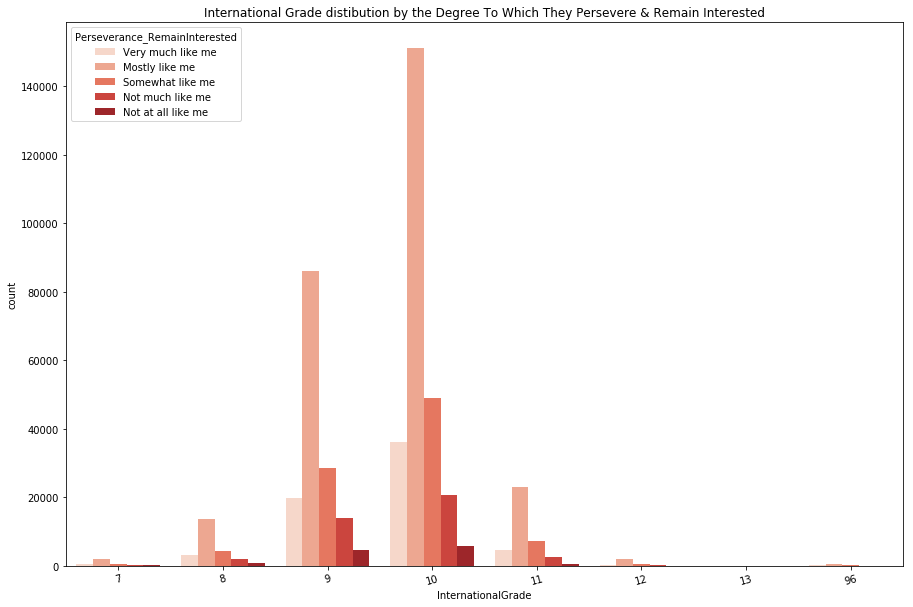

```python
# plot stacked bar chart
plt.figure(figsize = [15, 10])
sb.countplot(data = pisa_df, x = 'InternationalGrade', hue = 'Perseverance_RemainInterested',palette = 'Reds')
plt.xticks(rotation = 15);
plt.title('International Grade distibution by the Degree To Which They Persevere & Remain Interested')
plt.show()
```

**We observe that majority of students across all the grade bins feel they most likely to remain interested in their studies, we observed no clear correlation between performance and persevernace**

## Is Perseverance to remain interested correlated with the repeat grade ?

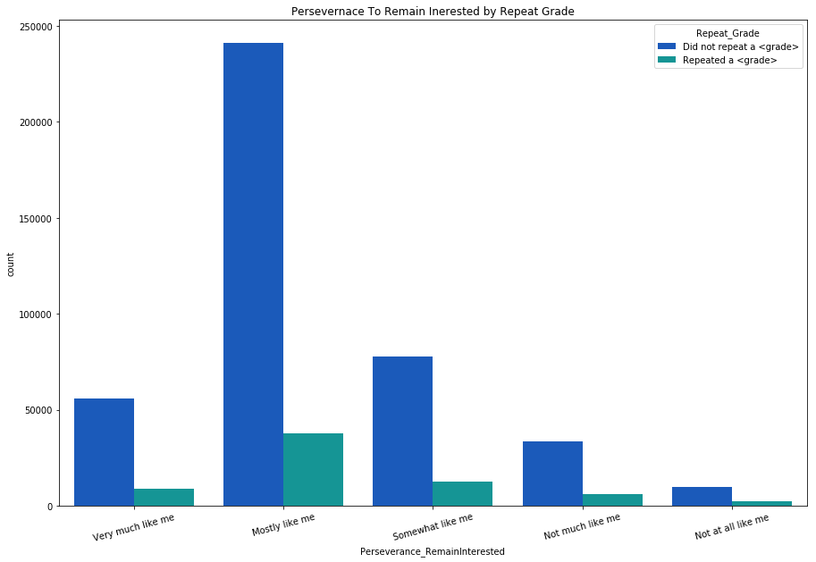

```python
# plot stacked bar chart
plt.figure(figsize = [15, 10])
sb.countplot(data = pisa_df, x = 'Perseverance_RemainInterested', hue = 'Repeat_Grade',palette = 'winter')
plt.xticks(rotation = 15);
plt.title('Persevernace To Remain Inerested by Repeat Grade')
plt.show()
```

**We observe that participants in bins less likely to remain interested have a higher ratio of repeats compared to participants more likely to remain interested**

## Does International grade correlate with parents' highest level of education?

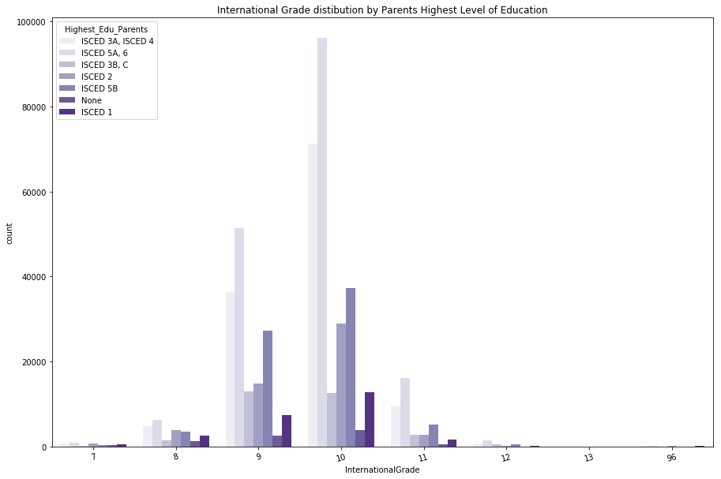

```python
# plot stacked bar chart
plt.figure(figsize = [15, 10])
sb.countplot(data = pisa_df, x = 'InternationalGrade', hue = 'Highest_Edu_Parents',palette = 'Purples')
plt.xticks(rotation = 15);
plt.title('International Grade distibution by Parents Highest Level of Education')
plt.show()
```

**If we look at the top grades, we can see that there isa correlation between parents education level and participant grade.**

### Talk about some of the relationships you observed in this part of the investigation. How did the feature(s) of interest vary with other features in the dataset?

> In the two highest grade bands (11&12) we observe that only a tiny amount of participants do not have computers at home

> We observe that majority of students across all the grade bins feel they most likely to remain interested in their studies, we observed no clear correlation between performance and persevernace

> If we look at the top grades, we can see that there isa correlation between parents education level and participant grade.

### Did you observe any interesting relationships between the other features (not the main feature(s) of interest)?

> We observe that participants in bins less likely to remain interested have a higher ratio of repeats compared to participants more likely to remain interested

## Is there a relationship between Age, Participants mother at home and International Grade

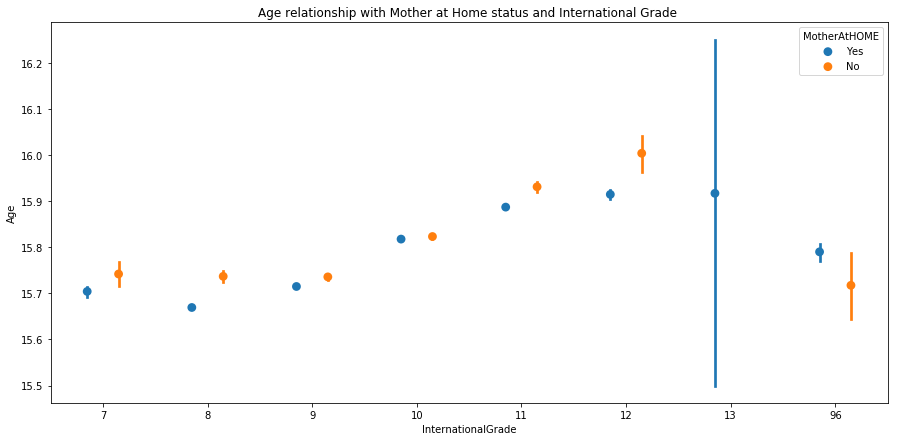

```python
#Point plot
plt.figure(figsize = [15, 7])
ax = sb.pointplot(data = pisa_df, x = 'InternationalGrade', y = 'Age', hue = 'MotherAtHOME',
                  dodge = 0.3, linestyles = "");
plt.title('Age relationship with Mother at Home status and International Grade ');
```

**We observe that across Grades 7 through to 12, that participants without their mothers at home are more likely to be slightly older than participants with their mothers at home.**

## Does Age impact the amount of books at home and International Grade

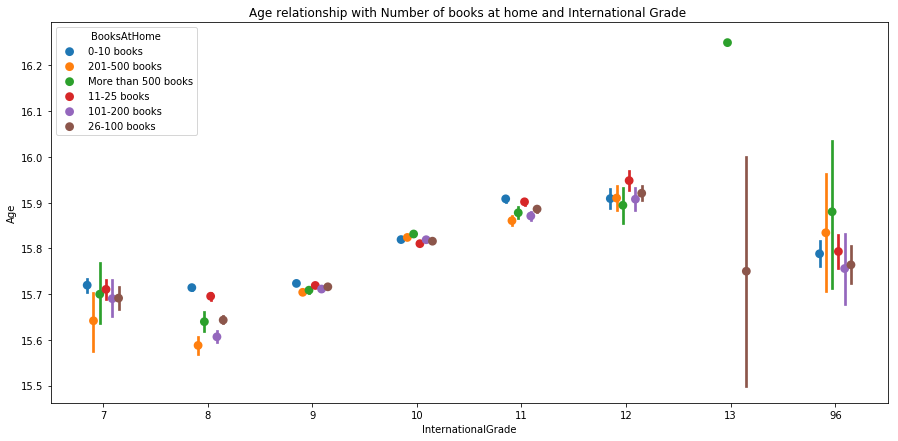

```python
#Point plot
plt.figure(figsize = [15, 7])
ax = sb.pointplot(data = pisa_df, x = 'InternationalGrade', y = 'Age', hue = 'BooksAtHome',
                  dodge = 0.3, linestyles = "");
plt.title('Age relationship with Number of books at home and International Grade ');
```

**We can observe a moderate positive correlation between age and international grade, between grades 8 and 12, there is a steady increase in age, however we do not observe any meaninful impact of books at home status on the other two varibales.**

## Is there a relationship between Age, participants' satisfaction with school and having internet at home?

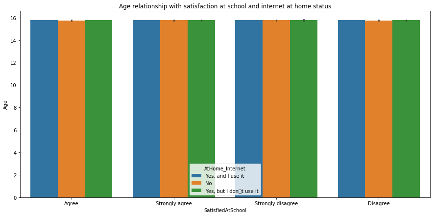

```python
# plot stacked bar chart
plt.figure(figsize = [15, 7])
ax = sb.barplot(data = pisa_df, x = 'SatisfiedAtSchool', y ='Age', hue = 'AtHome_Internet')
plt.title('Age relationship with satisfaction at school and internet at home status');
```

**Regardless of Age and satisfaction at school, there is an even internet at home status across board, we observe almost equal identical distributions of responses**

### Talk about some of the relationships you observed in this part of the investigation. Were there features that strengthened each other in terms of looking at your feature(s) of interest?

> We observe that across Grades 7 through to 12, that participants without their mothers at home are more likely to be slightly older than participants with their mothers at home.

> We can observe a moderate positive correlation between age and international grade, between grades 8 and 12, there is a steady increase in age, however we do not observe any meaninful impact of books at home status on the other two varibales.

### Were there any interesting or surprising interactions between features?

> Regardless of Age and satisfaction at school, there is an even internet at home status across board, we observe almost equal identical distributions of responses.

## Conclusions

> The objective of this analysis was to investigate factors tht contribute to student's academic performance based on the PISA assesment survey.

> We performed univirate, bivirate and multivirate explorations on attributes of interest such as International Grade, Age, Gender, parents' highest level of education, satisfaction at school e.t.c. to anwer questions about the relationships within our data.